### *Udacity Project 5: Communicate Data Findings*

# Ford GoBike Data Explanation

### by Kayin Patton

## Overview

I will be gathering, assessing, cleaning, and then visualizing explanatorily a Ford GoBike data set provided by Udacity. The Ford GoBike is a public bike sharing system in San Francisco, East Bay, and San Jose. The system launched on June 28, 2017 as a means to make commuting in the bay area much more accessible. Ford Motor Company partnered up with each township to ensure residents could get around with ease!

### Investigation Overview:

In the overall investigation I will be exploring the time spent, distance traveled, and ages of each member of this bike sharing system. I will specifically be looking into the ages and distance traveled of each member, but will be exploring all aspects of this data to attempt to get a wide, yet also thorough view of this dataset.

### Dataset Overview:

I chose this dataset specifically because I am an avid bike rider, and often wonder if systems like this are useful in any way. Combined with my interest in urban planning, it was a no brainer. I need to do figure out how to calculate the ages of each rider currently, and then do the same for distance. This way I'll be able to see all of the strands of this specific thread of the datasets rope.

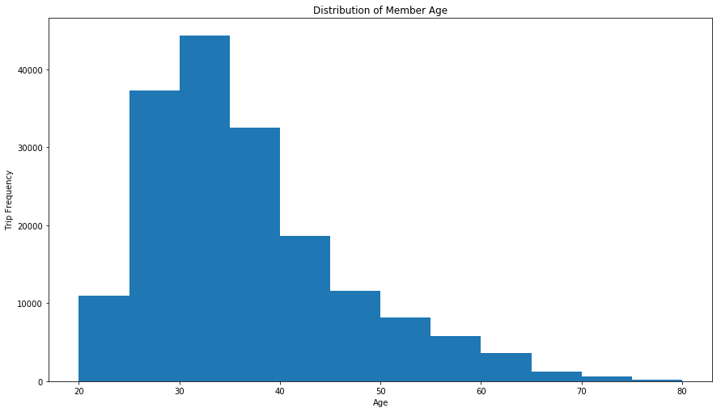

I don't really feel like I'm getting to much info from this histogram, so I'm going to try and scale it, so we can get a more accurate view on the ages with the most trips, and the lowest member age.

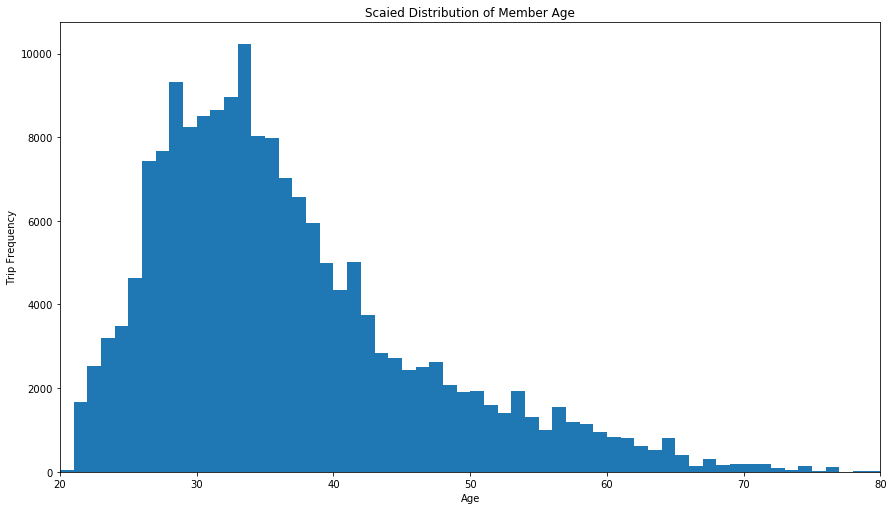

I attempted to log scale `age`, but it was getting a bit convoluted. So, let's try custom scaling it! I am interested in getting a deeper look into this variable.

### Age Distribution

Without a formal deep dive into these charts, you can already see that the age range for riders is wide! The initial histogram was helpful because it gave me a macro idea as to what the age range was, but I needed to see more. So, I decided to scale the initial histogram to try and get a more accurate view at where the majority age of riders were. As I had thought, and expected frankly, this variable is also unimodial. It looks like the majority of riders are in between ages 25 and 35 with a tail ending somewhere around 75-80 years old. I think it's awesome older folks were getting exercise by way of city bikes!

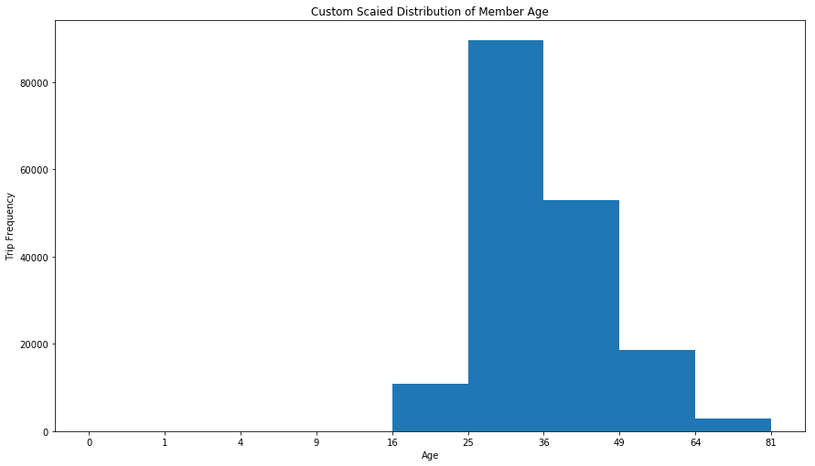

Okay, so, this is exactly what I was hoping to find with this exploration. You can see a more accurate age range with ages as young as 18 and as old as 80. But even more so, you can see that the majority of riders were somewhere in between 25 and 36 years old.

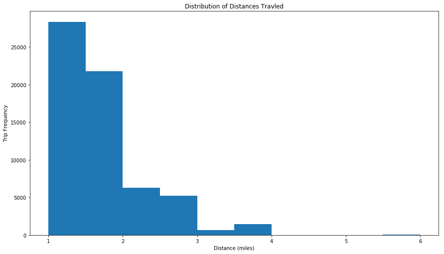

It looks like the trips didn't seem to go any further than 6 miles, with a cliff of trips being around 1 mile long. This is very helpful! But, I want to dive deeper. Maybe, something else will present itself.

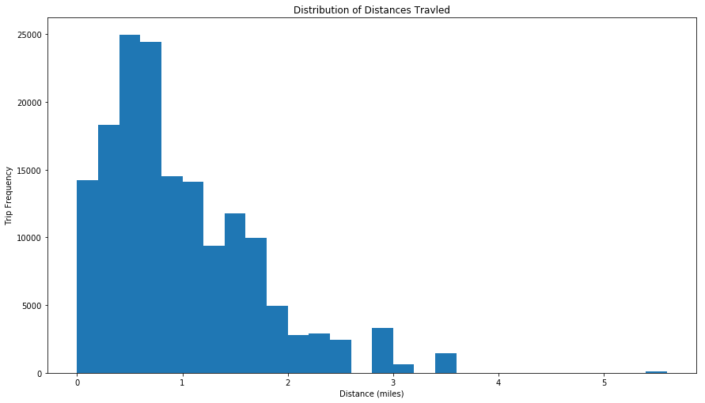

I scaled the plot out to see exactly where the start and end of `distance`'s range. You can see though that a good amount of trips were actually less than a mile long, despite what we saw earlier. Let's look deeper!

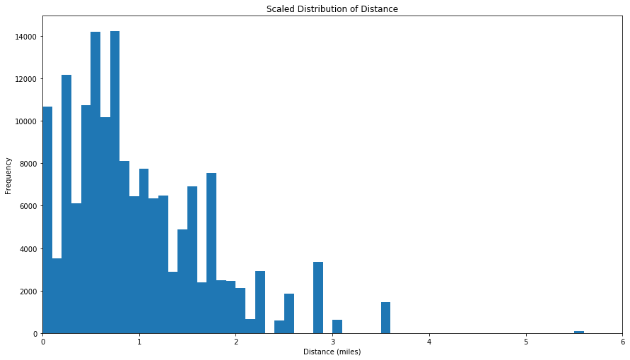

Here you can see that I used a scaled plot, to see even further into this subsection of data. It's becoming clearer the further I dive, that `distance` is not what it seems entirely.

### Distance Distribution

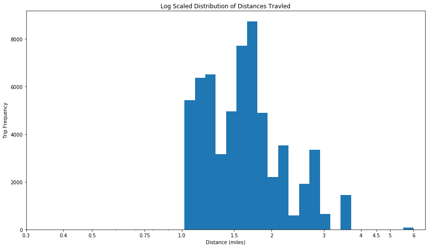

Now that I've log scale plotted for `distance`, I can see that there are a lot of trips taken in between 1.5 and 2 miles. This slightly bimodal plot shows that not many trips go further than 6 miles. Actually the furthest looks to be just under 6 miles, when I thought there might be some trips that went further. I wonder what the break down for rider types is? That could definitely shed some light on who's riding further!

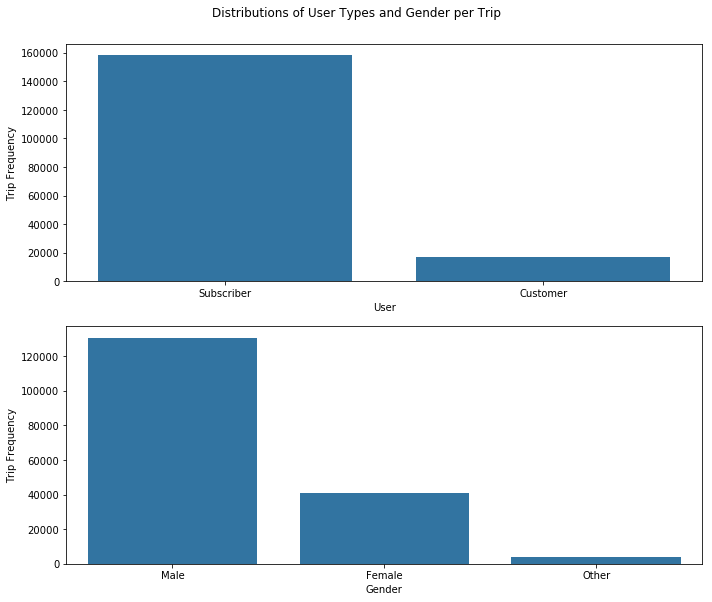

Here I wanted to give quick glimpse at the two categorical variables I'll be exploring. As you can see there are more Subscribers than Customers for `user_type` and for `member_gender` the plot suggests that the majority of trips were taken by male riders. Female riders and riders who identified as, Other, coming in a not-so-close second and third.

## Bivariate Exploration

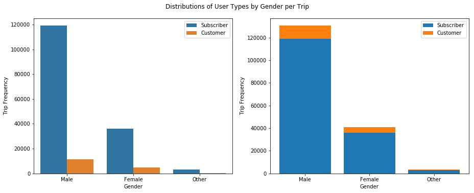

I wanted to showcase a stacked plot to show the relationship between categorical variables `user_type` and `member_gender` I believe it's important to show these as I will be comparing these two variables against the numerical variables I explored earlier in this analysis.

### Member Gender:

Let's see how the numerical values are represented via `member_gender`

### Member Gender vs Age:

Let's see how `age` is represented via `member_gender`.

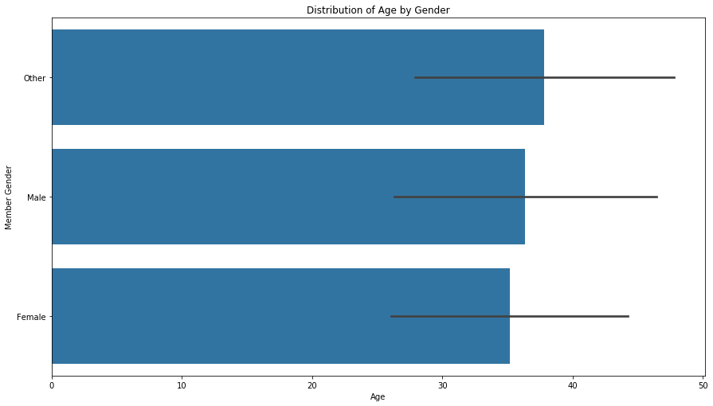

I am seeing a pattern here. Again, the smallest category has the strongest relationship with this variable. You can see that the age range for Other is wider, then the male age range, with the female age range have the least diversity.

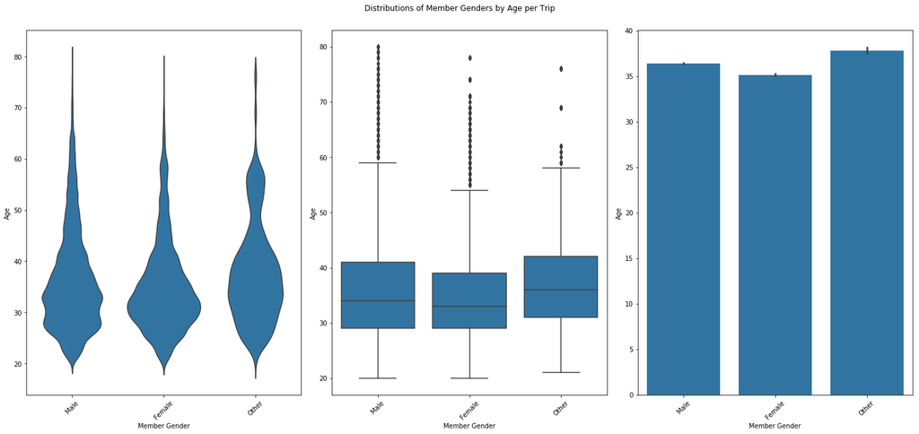

### Member Gender vs Distance:

Let's see how `distance` is represented via `member_gender`.

Finally when I plotted the relationship between `member_gender` and `distance` I found something specifically odd. Each gender category, as in, it didn't matter what each rider identified as in this case. This conclusion stems from the fact that each gender has traveled the same distances, or as close to the same distances as possible. Each bar looks equal to the last, and so do the standard deviations as well.

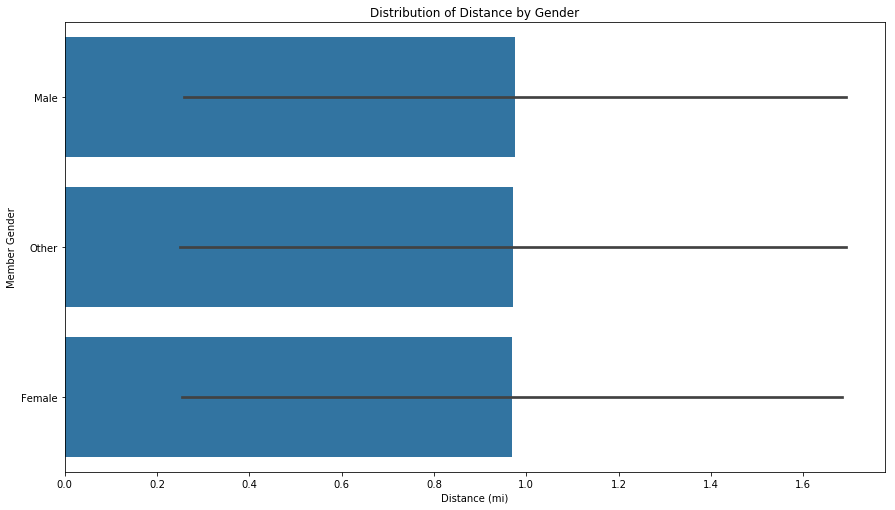

Here you can see that all of the gender types have the same range of distance traveled per trip. The standard deviations look to be the same as well.

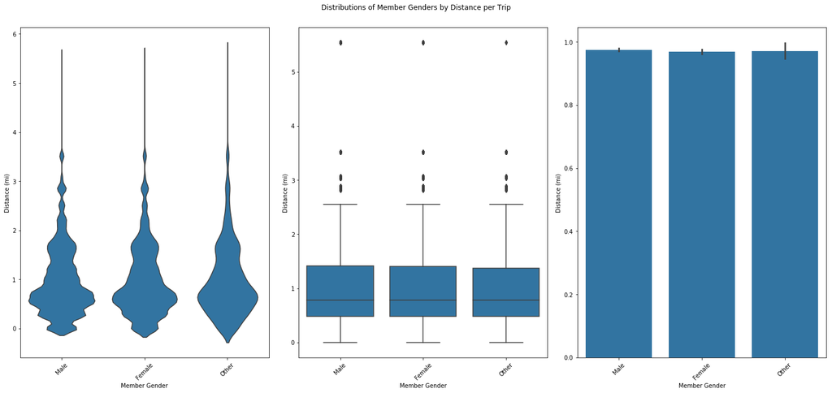

Here you can see the previous finding supported. What I will say is that distance traveled represented by rider gender seems like it would be a great baseline for some multivariate plotting. I will again make a note of this and continue on with my exploration.

## Multivariate Exploration

### Gender vs. Age vs. Distance: FacetGrid - Scatter

We can start to see the relationship between age and gender and that relationship with distance traveled. Despite what we've seen thus far, it looks like male riders have a wider range of ages but a small range of distance traveled. With female riders having an adverse reaction to being compared to age and distance. You can see that almost like the Other gender, female riders have a smaller range of rider ages (not by much though), but a much wider range of distance traveled. I wonder what makes the data so opposite for these variables...

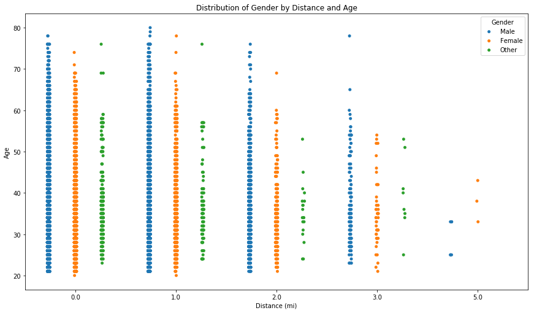

### Gender vs. Age vs. Distance: Polished FacetGrid

Here's a deeper dive!

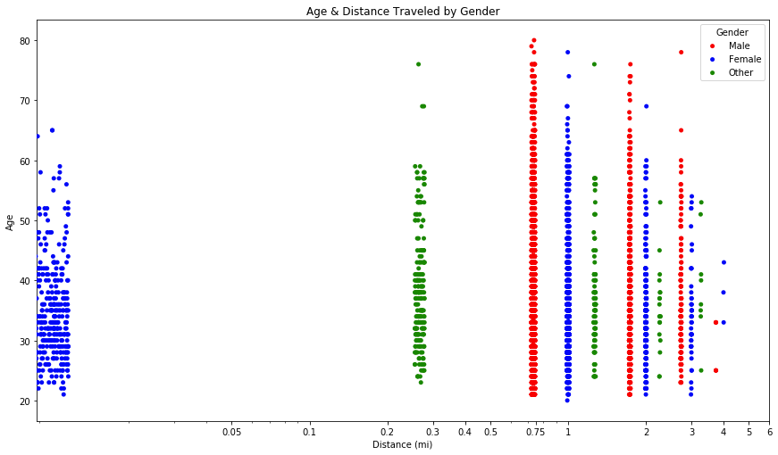

Here's something interesting about the gender types. They are rarely unable to surprise me! You can see that more female riders around 40 or younger took most of the shortest distance trips. With male riders having the bulk of their trips in the 0.75 to 1 mile range. I was expecting the other gender type to have a stronger reaction to age vs. distance; however, you can see in this log scaled facetgrid, that is not the case.

### Gender vs. Age vs. Distance: FacetGrid - Line

As I dive deeper into this you can see that something is really driving the gender type Other to be so volatile. I at first attributed this to be an outlier, and how some rules don't entirely apply. However, I'd also like to attribute this to potentially being driven by another categorical variable.

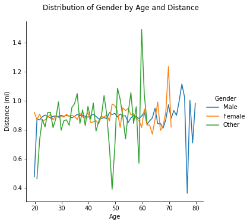

Here you can see more of the new relationship pattern being explored. Look at how volatile the green line is (Other). It is suggesting that older riders in the Other category rider further than other category. Funnily enough, the older male riders get, the shorter the distance of their trips are. Female riders seem to have the most steady age to distance traveled ratio.

### Gender and User Type vs. Age: Heatmap

As you can see the rider gender, Other, is also driven by the type of user the rider is as well. If they are also a Subscriber they have higher average rider age. Which definitely explains the volatility from earlier, as I would assume that more folks aren't chosing a gender as to expedite the processes, or due to lack of representation.

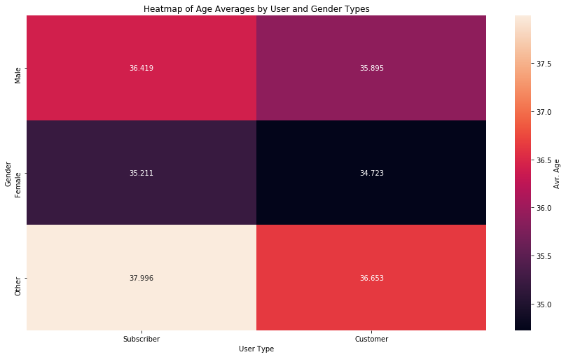

In this heatmap you can see that the highest average age belongs to the other-gender, subscriber-user group. With the lowest average in ages being the female-gender, customer-user group.

### Gender and User Type vs. Distance: Heatmap

Now, here is where things are a bit interesting. While it does to some degree help explain why the data is so volatile for the gender, Other, it doesn't really give me much more than the heatmap above. What I can see here is that it looks like more male riders travel further if they opt out of subscribing to the system altogether. Which I find very interesting!

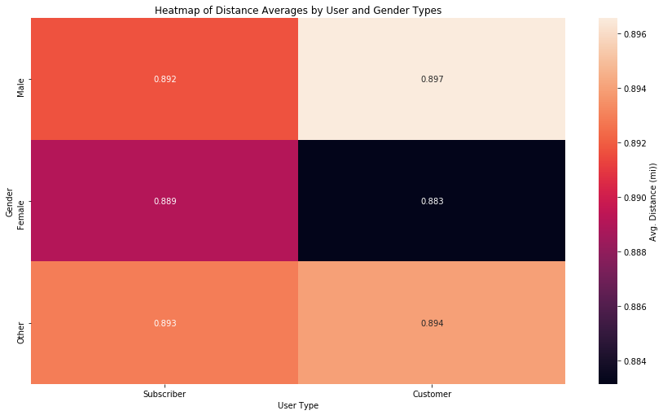

Lastly, you can see that the highest average of distance traveled belongs to the male customer group. Whereas the lowest average in distance traveled per trip is again the female customer group. What's most interesting about the distance heatmap is that each average for each is less than a mile. I wonder how many riders use the bike share system to get to and from work.